# La política de la corrupción

Sesión 12: Crimen organizado, violencia y captura del Estado

Bogdan G. Popescu

bgpopescu@tec.mx

Tecnológico de Monterrey

## Hoy

Acaban de verlo pasar con un solo hombre. La pregunta de esta hora:

**¿Cómo influyen las organizaciones criminales en los funcionarios públicos, y qué pasa cuando ese arreglo se rompe?**

Al terminar esta sesión, ustedes podrán:

- Explicar el *plata o plomo*: por qué los sobornos y las balas son sustitutos
- Explicar cómo la alternancia partidista rompió los pactos de protección entre Estado y cárteles en México
- Anticipar cómo los operativos contra el narco reconfiguran las rutas del trasiego y la violencia

Una advertencia: el tema de hoy toca de cerca a muchos de ustedes. Participen solo hasta donde quieran.

# I. Cuando el crimen compite por gobernar

## Diego consiguió lo que quería. ¿O no?

Hasta ahora, Diego le pagaba a la gente para que las cosas se hicieran. Esta vez estaba pagando para **que no lo lastimaran**.

- Durante meses, Diego le pagó a un grupo criminal. El arreglo era ilegal, pero **predecible**.
- Votó por una presidenta municipal que prometió combatir al crimen organizado.
- La policía detuvo al cobrador. Diego pensó que sus problemas se habían acabado.
- En cambio, **llegaron dos hombres**, cada uno exigiendo el pago y amenazando con las consecuencias.

**¿Por qué Diego quedó menos seguro justo cuando el gobierno por fin enfrentó al crimen organizado?**

¿Y qué nos dice esto sobre la relación entre **organizaciones criminales, políticos y violencia**?

La historia de Diego sugiere algo incómodo: **romper un arreglo criminal a veces produce más violencia, no menos.**

## México: lo desconcertante es el momento

La historia de Diego es ficticia. Pero México vivió una transformación real: el PRI fue perdiendo poco a poco su monopolio del poder político.

¿Qué pasó con la violencia?

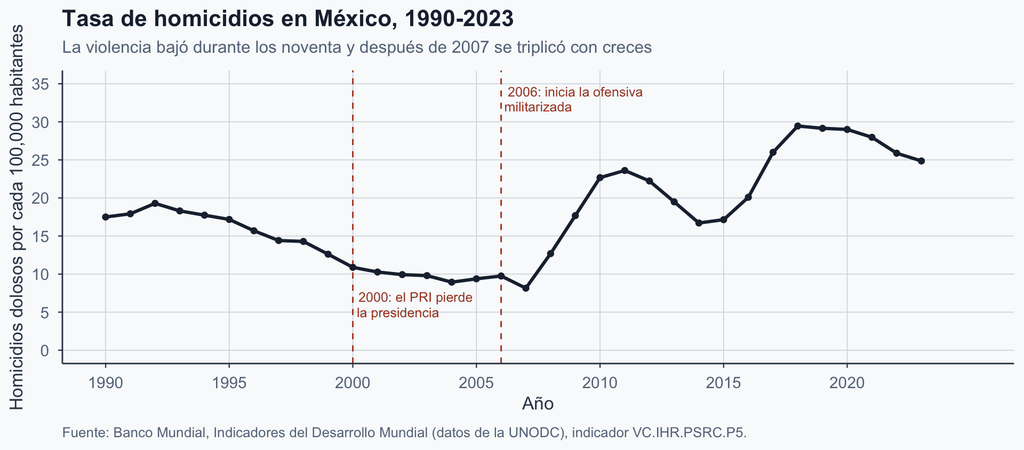

## México: lo desconcertante es el momento

- **De 1989 en adelante:** los partidos de oposición empezaron a ganar gubernaturas
- **2000:** el PRI perdió la presidencia después de 71 años
- **2007:** la tasa de homicidios tocó su punto más bajo de la serie
- **Después de 2007:** la violencia aumentó de manera drástica

**Si la alternancia política rompió los arreglos de protección criminal, ¿por qué la violencia tardó tanto en dispararse?**

## La zona gris de la criminalidad

Las organizaciones criminales no solo rompen reglas: también las **hacen**. Cobran cuotas, ofrecen protección y castigan a quien desafía su autoridad. Esto es **gobernanza criminal**.

Pero rara vez gobiernan solas. Los funcionarios del Estado pueden tolerarlas, protegerlas o cooperar con ellas.

La competencia no es simplemente crimen *contra* orden, sino **quién** lo provee — y a veces **el Estado y los criminales lo hacen juntos**.

```
flowchart LR
  S["Agentes de<br/>seguridad del Estado"]
  C["Empresarios<br/>criminales"]
  Z["LA ZONA GRIS<br/>acuerdos informales"]
  R["Reglas sobre<br/>quién opera<br/>dónde"]
  Q["Menos violencia abierta<br/>mientras el acuerdo aguanta"]

  S --> Z
  C --> Z
  Z --> R
  R -.-> Q

  classDef st fill:#e2eaf3,stroke:#334155,color:#1e293b
  classDef cr fill:#f7e2db,stroke:#b44527,color:#1e293b
  classDef gz fill:#f0e6c9,stroke:#b7943a,color:#1e293b
  classDef ok fill:#e2ede9,stroke:#4a7c6f,color:#1e293b

  class S st
  class C cr
  class Z gz
  class R,Q ok
```

Concepto y redacción tomados de Trejo y Ley (2020, cap. 1).

## ¿Y entonces?

- El crimen organizado necesita funcionarios: no puede operar solo con violencia
- La zona gris es un **intercambio**, y los intercambios tienen precio
- Entonces conviene preguntar: ¿cuánto **cuesta** capturar a un funcionario?
- ¿Y qué cambia cuando el comprador además puede disparar?

Sigue: un modelo sencillo que responde las dos preguntas.

# II. Plata o plomo: la lógica de la influencia armada

## El mismo policía. El mismo favor.

Un policía controla el retén de la carretera que pasa junto al patio de obra de Diego.

Llegan dos camiones en días distintos. A los dos les faltan papeles. Dejar pasar a cualquiera de ellos podría costarle el trabajo al policía.

- **Lunes:** Diego le pide al policía que deje pasar su camión. El policía exige **100** por correr el riesgo. Diego paga.
- **Martes:** llega un chofer del cártel con el mismo problema. Ofrece **40**.
- El policía se niega. El chofer se le acerca: **“Usted ya sabe qué les pasa a los que se nos atraviesan.”**

**¿Por qué el policía aceptaría 40 del cártel después de exigirle 100 a Diego?**

## El precio de decir que sí

El policía enfrenta el mismo costo personal en ambas situaciones: **c = 100**.

- **Diego:** solo puede ofrecer dinero. Tiene que pagar **b = 100**.
- **El cártel:** puede ofrecer dinero **y amenazar con un castigo**.
- Si el castigo amenazado vale **p = 60** para el policía, al cártel le basta con pagar **b = 40**.

**El cártel no hizo que la corrupción fuera menos riesgosa. Hizo que negarse fuera más peligroso.**

## La misma decisión, comprada de dos maneras

Comprar la misma presión con **dinero** en vez de **miedo** cuesta más

## Resultado: la violencia abarata la influencia

- El miedo sustituye al efectivo, así que un grupo armado nunca paga el precio completo: solo **c − p**
- La influencia es más barata para quien puede amenazar, así que **más grupos pueden pagarla**
- Y el dinero que sí se ve **subestima** la influencia que realmente se compró

“Los políticos coaccionados venderán sus favores relativamente baratos.”

Dal Bó, Dal Bó y Di Tella (2006), Proposiciones 2, 4 y 5 — también su respuesta a la paradoja de Tullock sobre lo poco que se gasta en cabildeo.

## ¿Combatir el soborno puede empeorar la intimidación?

De vuelta en el retén. El cártel ofrece **40 en efectivo** y **60 en castigo amenazado** para que su camión pase. El gobierno introduce dos reformas.

**A. Rastrear el dinero.** Pagar sobornos se vuelve más riesgoso. Pero amenazar al policía sigue siendo igual de fácil que antes.

- Si el cártel sigue intentándolo, puede pasarse a **20 en efectivo y 80 en amenazas**

**B. Proteger al policía.** El gobierno protege a su familia y dificulta la intimidación. Pagar sobornos sigue siendo igual de fácil que antes.

- Si el cártel sigue intentándolo, puede pasarse a **67 en efectivo y 33 en amenazas**

**La lección:** cuando un instrumento se encarece, los grupos criminales pueden sustituirlo por el otro.

Y fíjense en lo que A le hace a las estadísticas oficiales: **se observan menos sobornos, aunque al policía lo sigan coaccionando.**

## ¿Cuándo se rinde el cártel?

Hay algo que nuestros ejemplos han dado por sentado: **que el cártel todavía quiere comprar la cooperación del policía.** Pero influir en un funcionario cuesta dinero y recursos.

- **Encarecer sobornos y amenazas.** En algún punto, influir en el policía puede costar más de lo que el cártel gana
- **Quitarle la decisión.** Inspecciones automáticas y registradas: el policía ya no puede dejar pasar camiones por su cuenta
- Si el policía no tiene nada valioso que ofrecer, ¿para qué pagarle o amenazarlo?

**Dos maneras de combatir la influencia criminal: encarecerla o quitarle valor.**

Esto explica la influencia **armada**, no la influencia en general:

- Diego necesita a ese policía igual de urgentemente y sigue pagando el precio completo; lo que le falta es una forma creíble de hacerle daño.

## ¿Y entonces?

- El modelo dice que la influencia armada es **barata** y, sobre todo, **silenciosa**
- Pero el arreglo es un apretón de manos: informal, sin papeles, sin un juez detrás
- Así que dura solo mientras quienes se dieron la mano sigan en el cargo

Ya sabemos por qué un cártel puede comprar barato a un funcionario. **Pero ¿qué pasa cuando los políticos que protegían a ese cártel pierden el puesto?**

# III. México: cómo la democratización rompió el pacto

## El viejo pacto de protección

```
flowchart LR
  A["El PRI domina<br/>la política estatal"]
  B["Policías y fiscales<br/>protegen a los traficantes"]
  C["Los traficantes pagan<br/>y acatan reglas informales"]
  D["Menos pleitos abiertos<br/>entre cárteles"]

  A --> B
  B --> C
  C --> D

  classDef pol fill:#e2eaf3,stroke:#334155,stroke-width:3px,color:#1e293b
  classDef crm fill:#f7e2db,stroke:#b44527,stroke-width:3px,color:#1e293b
  classDef out fill:#e2ede9,stroke:#4a7c6f,stroke-width:3px,color:#1e293b
  class A,B pol
  class C crm
  class D out
```

Ilustración del autor a partir de Trejo y Ley (2020, cap. 1). El resto conviene decirlo en voz alta: la protección les permitía operar, y las reglas informales evitaban que pelearan entre ellos por ella.

## El choque: las elecciones empiezan a cambiar gobernadores

- 1989: Ernesto Ruffo Appel gana Baja California, el primer gobernador no priista desde 1929
- Las victorias de la oposición se extienden por los estados durante los noventa
- 2000: el PRI pierde la presidencia después de 71 años
- Los gobernadores entrantes cambiaron a jefes policiacos y procuradores estatales
- Esos eran justamente los puestos donde se había negociado la protección

La democratización avanzó **más rápido que la reforma policial y judicial**.

Imaginen que controlan una ruta de trasiego valiosa. Durante años, la policía del gobernador protegió sus operaciones.

Entonces gana un gobernador de oposición y cambia al jefe de la policía.

**Sus rivales saben que tal vez ya no estén protegidos. ¿Qué pasa después?**

## Trejo y Ley: cómo un pacto se vuelve guerra

```
%%{init: {"theme":"base","themeVariables":{"fontSize":"20px","fontFamily":"Helvetica Neue, Helvetica, Arial, sans-serif","primaryColor":"#f1f5f9","primaryTextColor":"#1e293b","primaryBorderColor":"#334155","lineColor":"#64748b"},"flowchart":{"useMaxWidth":true,"htmlLabels":false,"nodeSpacing":170,"r…
flowchart LR
  A["Gana un gobernador<br/>de oposición"]
  B["Cambian policías<br/>y fiscales"]
  C["La vieja protección<br/>se vuelve incierta"]
  D["Los cárteles arman<br/>milicias privadas"]
  E["Los rivales pelean<br/>por el territorio"]

  A --> B
  B --> C
  C --> D
  D --> E

  classDef pol fill:#e2eaf3,stroke:#334155,stroke-width:3px,color:#1e293b
  classDef unc fill:#f0e6c9,stroke:#b7943a,stroke-width:4px,color:#1e293b
  classDef war fill:#f7e2db,stroke:#b44527,stroke-width:3px,color:#1e293b
  class A,B pol
  class C unc
  class D,E war
```

Ilustración del autor a partir de Trejo y Ley (2018, 2020). Más vale decirlo en voz alta que dibujarlo: una vez que empiezan los pleitos, alimentan la misma incertidumbre que los provocó.

## El territorio es el premio

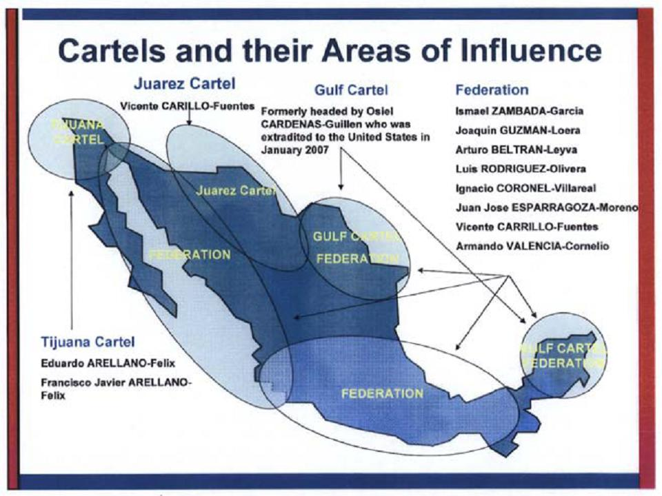

Los cárteles y sus áreas de influencia declaradas en México, 2008

Esta es una foto tomada **ya bien entrada la escalada**: todavía un puñado de bloques grandes.

Lo que la década siguiente le hizo: descabezar organizaciones las fragmenta en vez de disolverlas.

## De repartido a disputado

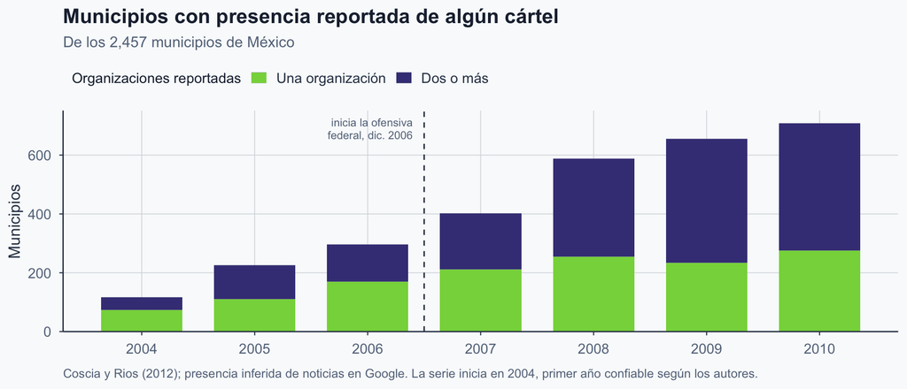

- 2004: **116** municipios, 42 de ellos con más de una organización
- 2010: **709** municipios, **433** de ellos con más de una
- De 2008 en adelante, la mayor parte del territorio de los cárteles está **en disputa**, no simplemente ocupado

Presencia reportada, no presencia: la medida cuenta municipios donde las noticias y los blogs nombraron a una organización, así que el aumento de cobertura en la web infla algo la tendencia — la imagen en espejo del problema de siempre, donde la coacción silenciosa no se cuenta. Corroboración independiente de la dirección: el censo de Crisis Group cuenta 76 grupos armados en 2010 y 205 para finales de 2020.

## Dónde se extendió la disputa

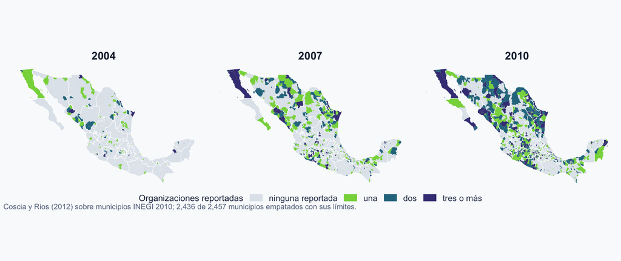

## ¿Qué diferencia hace una elección cerrada?

Trejo y Ley estudiaron qué pasa cuando cambian los **gobernadores**. Dell (2015) se fija en los **presidentes municipales**.

Imaginen dos municipios que celebran elecciones:

- **Municipio A:** el PAN pierde por apenas 0.1 puntos porcentuales.
- **Municipio B:** el PAN gana por apenas 0.1 puntos porcentuales.
- ¿Esperarían que estos municipios tuvieran niveles de violencia muy distintos?

Probablemente no. En elecciones muy cerradas, los municipios de un lado y otro deberían parecerse **en promedio**.

Pero uno se queda con un **alcalde del PAN** y el otro no.

**¿Por qué importaría eso?** Los alcaldes nombran al jefe de la policía. Los alcaldes del PAN estaban más dispuestos a enfrentar a los traficantes, muchas veces con apoyo federal.

**Entonces, ¿qué pasa con la violencia cuando el PAN gana por un pelo?**

Dell (2015). La comparación entre elecciones cerradas identifica el efecto de una victoria del PAN; el aumento de los operativos es un mecanismo propuesto.

[figure not shown]

## De dónde sale la estimación

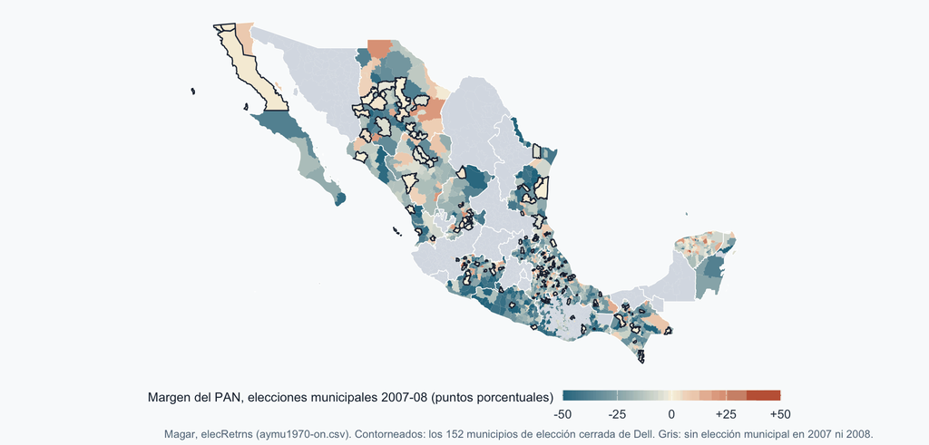

## El salto aparece solo cuando el alcalde toma posesión

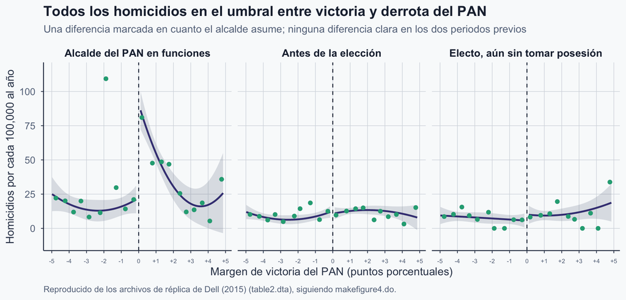

- **A la izquierda del cero:** el PAN perdió por poco. **A la derecha:** ganó por poco.
- **En cuanto el alcalde asume:** la violencia salta del lado donde ganó el PAN.
- **Antes de la elección:** ninguna diferencia clara en el umbral.
- **Después de la elección, antes de la toma de posesión:** tampoco hay diferencia clara.

**¿Por qué solo después de que el nuevo alcalde toma posesión?**

Dell (2015), figura 4. Las victorias cerradas del PAN son el tratamiento; el aumento de los operativos es una de las explicaciones propuestas.

## Dell (2015): el resultado principal

Donde el PAN ganó por poco en vez de perder por poco, a lo largo del periodo del alcalde:

- **+57** homicidios totales por cada 100,000 habitantes al año
- **+33** homicidios ligados al narcotráfico por cada 100,000 habitantes al año

Lo que se movió fue la **intensidad** de la violencia, no si ocurría o no: la probabilidad de que haya *algún* homicidio en un mes casi no cambió.

La diferencia apareció **después de que el nuevo alcalde tomó posesión**, y eso es lo que apunta a los operativos:

- debilitaron al traficante que ya estaba y le abrieron el municipio a los rivales.

## Diecisiete años de nada y luego un precipicio

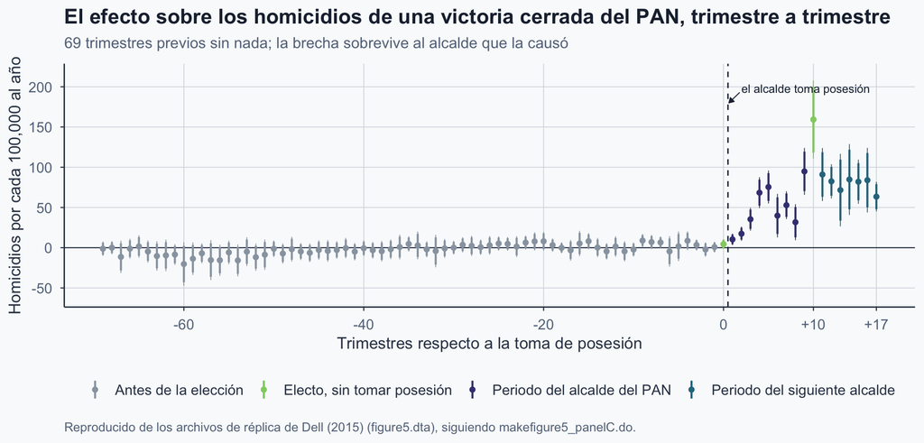

Figura 5, panel C de Dell. Las barras gruesas son intervalos al 90% y las delgadas al 95%. Uno de los 69 trimestres previos a la elección resulta significativo: menos de los que daría el azar por sí solo.

## ¿Por qué combatir al narco elevaría la violencia?

```
%%{init: {"theme":"base","themeVariables":{"fontSize":"20px","fontFamily":"Helvetica Neue, Helvetica, Arial, sans-serif","primaryColor":"#f1f5f9","primaryTextColor":"#1e293b","primaryBorderColor":"#334155","lineColor":"#64748b"},"flowchart":{"useMaxWidth":true,"htmlLabels":false,"nodeSpacing":110,"r…
flowchart LR
  A["Victoria cerrada del PAN:<br/>nuevo alcalde,<br/>nuevo jefe policiaco"]
  B["El traficante que<br/>controlaba el municipio<br/>queda debilitado"]
  C["Pero la ruta que<br/>pasa por ahí sigue<br/>valiendo la pena"]
  D["¿Hay un rival<br/>lo bastante cerca<br/>para tomarla?"]
  E["Entran los rivales:<br/>guerra por el<br/>territorio"]
  F["No llega nadie:<br/>el municipio<br/>sigue tranquilo"]

  A --> B
  B --> C
  C --> D
  D -->|"colinda con un rival"| E
  D -->|"aliados, o solo una banda local"| F

  classDef pol fill:#e2eaf3,stroke:#334155,stroke-width:3px,color:#1e293b
  classDef crm fill:#f7e2db,stroke:#b44527,stroke-width:3px,color:#1e293b
  classDef unc fill:#f0e6c9,stroke:#b7943a,stroke-width:4px,color:#1e293b
  classDef ok  fill:#e2ede9,stroke:#4a7c6f,stroke-width:3px,color:#1e293b
  class A pol
  class B,C crm
  class D unc
  class E crm
  class F ok
```

Los operativos quitan al **defensor**, no al **premio**.

## ¿Dónde debería ser mayor el efecto?

Debilitar a un cártel debería provocar más violencia **¿dónde?** Pidan tres hipótesis al salón antes del siguiente clic.

- En las 152 elecciones cerradas en conjunto: **+33** homicidios ligados al narco por cada 100,000 al año
- **Cerca de la frontera con EE. UU.: +38.** Lejos de ella, **-12** — indistinguible de cero, es decir, ningún efecto
- **Ya violentos antes de 2007: +37.** En municipios antes tranquilos, **-14** — el único corte donde la violencia, si acaso, *bajó*
- **Junto a un cártel rival: +31.** Junto a puros aliados, **+9**; frente a una simple banda local, **-2** — ninguno distinguible de cero

## Un operativo, tres municipios

```
%%{init: {"theme":"base","themeVariables":{"fontSize":"20px","fontFamily":"Helvetica Neue, Helvetica, Arial, sans-serif","primaryColor":"#f1f5f9","primaryTextColor":"#1e293b","primaryBorderColor":"#334155","lineColor":"#64748b"},"flowchart":{"useMaxWidth":true,"htmlLabels":false,"nodeSpacing":120,"r…
flowchart LR
  G["Zona de<br/>cultivo"]
  A["Municipio A"]
  B["Municipio B<br/>operativo aquí:<br/>caro de cruzar"]
  C["Municipio C<br/>sin operativo,<br/>sin elección"]
  X["Cruce a<br/>EE. UU."]

  G --> A
  A -.->|"ruta vieja,<br/>ahora cara"| B
  B -.-> X
  A ==>|"el trasiego<br/>se desvía"| C
  C ==> X

  classDef route fill:#e2eaf3,stroke:#334155,stroke-width:3px,color:#1e293b
  classDef hit fill:#f7e2db,stroke:#b44527,stroke-width:3px,color:#1e293b
  classDef new fill:#f0e6c9,stroke:#b7943a,stroke-width:4px,color:#1e293b
  class G,A,X route
  class B hit
  class C new
```

En el municipio C nunca hubo operativo y nadie votó por uno. **Si la droga empieza a pasar por C, ¿qué más llega ahí?**

Alguien ya controla C. Ahora hay algo que vale la pena quitarle.

## Cómo un operativo mueve una ruta

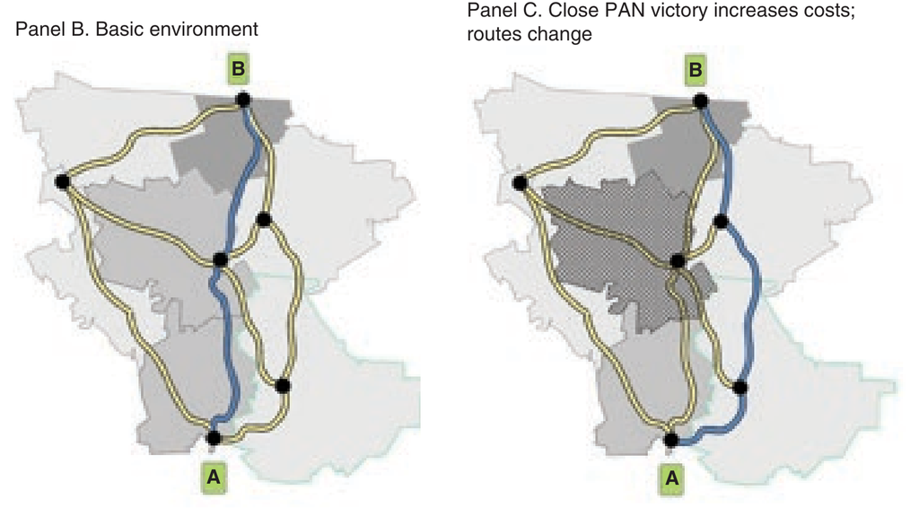

**Izquierda, antes:** la forma más barata de ir de A a B sube justo por en medio. **Derecha:** una victoria cerrada del PAN encarece el cruce por el municipio rayado, y el mismo trayecto se recorre hacia el este, por otra cadena de caminos. El azul es la ruta elegida, el verde olivo los caminos disponibles, los puntos los nodos.

## Las rutas, reconstruidas con sus datos

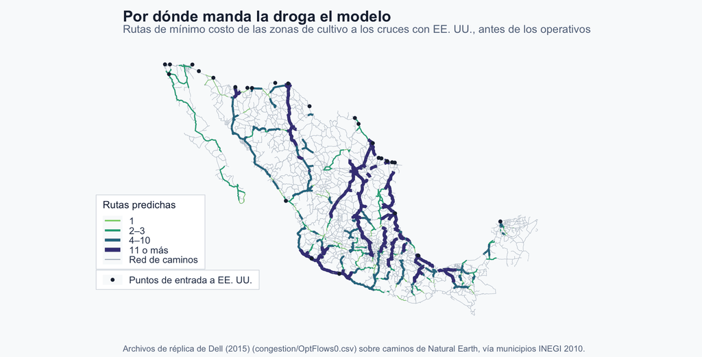

## A dónde se fue el trasiego

Un operativo vuelve más peligrosa una ruta de trasiego. Pero la droga sigue necesitando llegar a Estados Unidos.

Dell modela la red carretera de México para predecir a dónde se irían los traficantes en su lugar.

- **¿De verdad se desvían?** Donde el modelo predice una ruta nueva, el valor de los decomisos sube **18%**.
- **¿La violencia los sigue?** La probabilidad mensual de un homicidio ligado al narco sube de **4.8% a 6.2%**.
- **¿Dónde es mayor la violencia?** Hay algo de evidencia de aumentos más grandes donde convergen varias rutas.

**Un operativo en un municipio puede aumentar la violencia en otro.**

El gobierno puede interrumpir una ruta de trasiego sin detener el trasiego mismo.

Dell (2015), tablas 6–7. Las rutas predichas se validan contra los decomisos de droga; la evidencia sobre la violencia donde las rutas se traslapan es sugerente.

# IV. ¿Qué debería hacer el Estado?

## ¿Cuentan la misma historia estos dos trabajos?

- Trejo y Ley: la política rompe el pacto y luego los rivales se arman
- Dell: los operativos debilitan al que estaba y luego entran los rivales
- Choques distintos, misma forma: se altera un equilibrio existente
- La violencia sube donde se rompe el viejo orden, no donde está el crimen
- Ninguno de los dos trabajos afirma que el viejo equilibrio fuera bueno para la gente

La lección compartida: **alterar un orden criminal puede elevar la violencia antes de bajarla.**

## La pregunta incómoda

Diego quería que el cártel se fuera. La policía detuvo a su cobrador. Pero ahora dos grupos rivales lo están amenazando.

- **¿El gobierno debió haber dejado en paz al cártel?**
- Tolerar el viejo arreglo significaba aceptar extorsión, corrupción e impunidad.
- Pero desmantelarlo sin restablecer el orden creó oportunidades para los grupos rivales.

**¿Cómo puede el Estado enfrentar al crimen organizado sin dejar más expuesta a gente como Diego?**

## Ideas centrales

- **Plata o plomo:** las amenazas pueden sustituir a los sobornos, lo que abarata la influencia política y la hace más difícil de detectar.
- **Reformas anticorrupción:** encarecer el soborno puede empujar a los grupos armados hacia la intimidación.
- **Alternancia política:** cambiar gobernadores y mandos de seguridad puede romper los arreglos de protección criminal y detonar guerras territoriales.
- **Operativos:** debilitar a un cártel puede invitar los ataques de sus rivales y redirigir el trasiego — y la violencia — hacia otros municipios.

Tres mecanismos, no uno: **amenazas contra funcionarios, guerras entre cárteles y violencia que se derrama hacia otros municipios.**

Nada de esto significa que la democracia cause violencia ni que los operativos siempre salgan contraproducentes. Estos efectos dependen de las instituciones y de la competencia criminal que haya en cada lugar.

**Romper el control criminal no es lo mismo que reemplazarlo con control estatal.**

## Referencias

Acemoglu, D., De Feo, G., & De Luca, G. (2020). Weak states: Causes and consequences of the Sicilian Mafia. *The Review of Economic Studies, 87*(2), 537–581. https://doi.org/10.1093/restud/rdz009

Dal Bó, E., Dal Bó, P., & Di Tella, R. (2006). “Plata o plomo?”: Bribe and punishment in a theory of political influence. *American Political Science Review, 100*(1), 41–53. https://doi.org/10.1017/S0003055406061995

Dell, M. (2015). Trafficking networks and the Mexican drug war. *American Economic Review, 105*(6), 1738–1779. https://doi.org/10.1257/aer.20121637

Trejo, G., & Ley, S. (2018). Why did drug cartels go to war in Mexico? Subnational party alternation, the breakdown of criminal protection, and the onset of large-scale violence. *Comparative Political Studies, 51*(7), 900–937. https://doi.org/10.1177/0010414017720703

Trejo, G., & Ley, S. (2020). *Votes, drugs, and violence: The political logic of criminal wars in Mexico*. Cambridge University Press. https://doi.org/10.1017/9781108894807